# STAT318/462 Lab 7: Cluster analysis

In this lab you will work through Section 10.5 of the course textbook, An Introduction to Statistical Learning (there is a link to this textbook on the Learn page). The R code from Section 10.5 is given below. I have added R code for computing the silhouette coefficient and distance matrices.

You should play around with this R code and data in order to explore and gain a feel for how each of the two clustering algorithms work.

## First example data set

First, we construct a dataset to analyse using cluster analysis and hierarchical cluster analysis:

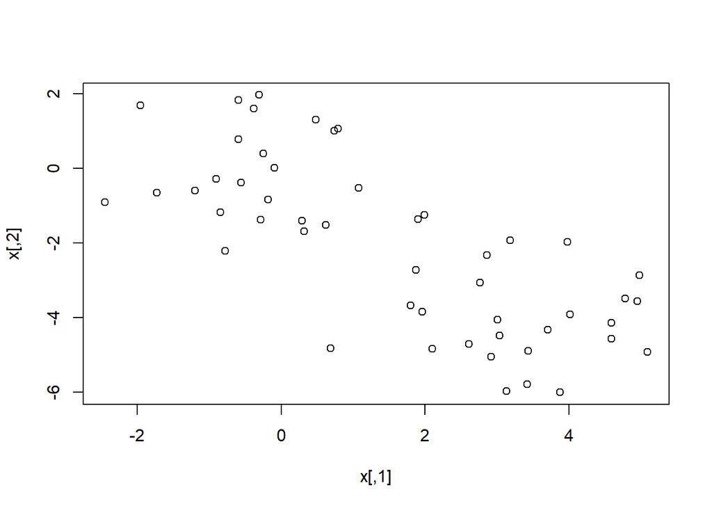

```r
set.seed(2)
x = matrix(rnorm(50 * 2), ncol = 2)
x[1:25, 1] = x[1:25, 1] + 3
x[1:25, 2] = x[1:25, 2] - 4
plot(x)
```

### Cluster analysis using K-means clustering

We can cluster the data, specifying that there should be 2 clusters (k=2). We specify 20 there should be 20 runs of the algorithm, each with a different initial random allocation of points to clusters:

```r
km.out = kmeans(x, 2, nstart = 20)
km.out$cluster
```

```
##  [1] 1 1 1 1 1 1 1 1 1 1 1 1 1 1 1 1 1 1 1 1 1 1 1 1 1 2 2 2 2 2 2 2 2 2 2
## [36] 2 2 2 2 2 2 2 2 2 2 2 2 2 2 2
```

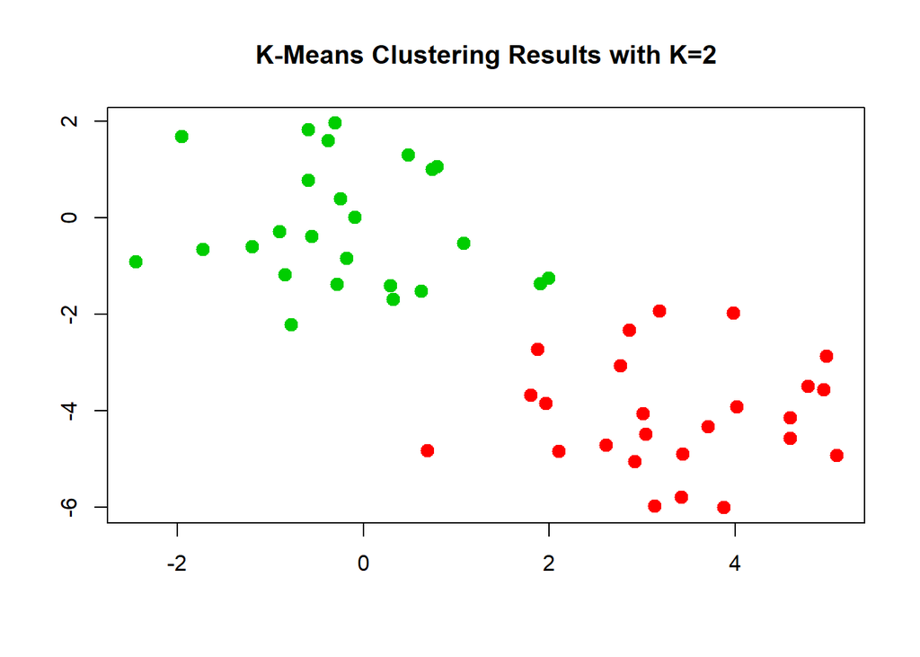

```r
plot(x, col = (km.out$cluster  +1),
     main = "K-Means Clustering Results with K=2",
     xlab = "", ylab = "", pch = 20, cex = 2)
```

Then repeat the same steps but specifying 3 clusters (k=3), again with 20 different runs of the algorithm:

```r
set.seed(4)
km.out = kmeans(x, 3, nstart = 20)
km.out
```

```
## K-means clustering with 3 clusters of sizes 17, 23, 10
##
## Cluster means:
##         [,1]        [,2]
## 1  3.7789567 -4.56200798
## 2 -0.3820397 -0.08740753
## 3  2.3001545 -2.69622023
##
## Clustering vector:
##  [1] 1 3 1 3 1 1 1 3 1 3 1 3 1 3 1 3 1 1 1 1 1 3 1 1 1 2 2 2 2 2 2 2 2 2 2
## [36] 2 2 2 2 2 2 2 2 3 2 3 2 2 2 2
##
## Within cluster sum of squares by cluster:
## [1] 25.74089 52.67700 19.56137
##  (between_SS / total_SS =  79.3 %)
##
## Available components:
##
## [1] "cluster"      "centers"      "totss"        "withinss"
## [5] "tot.withinss" "betweenss"    "size"         "iter"
## [9] "ifault"
```

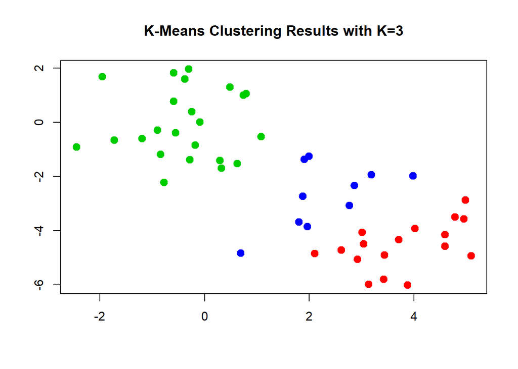

```r
plot(x, col = (km.out$cluster + 1),
     main = "K-Means Clustering Results with K=3",
     xlab = "", ylab = "", pch = 20, cex = 2)
```

Since the result depends on the initial random allocation of points to clusters, we can compare the decision of which points lie in which clusters for a single run of the algorithm:

```r
set.seed(3)
km.out = kmeans(x, 3, nstart = 1)
km.out$tot.withinss
```

```
## [1] 97.97927
```

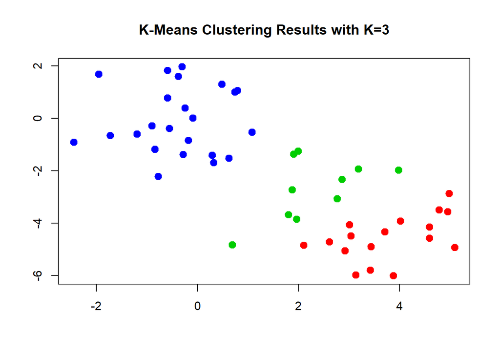

```r
plot(x, col = (km.out$cluster + 1),
     main = "K-Means Clustering Results with K=3",
     xlab = "", ylab = "", pch = 20, cex = 2)
```

with the outcome when we specify 100 different runs, and select the ‘best’:

```r
km.out = kmeans(x, 3, nstart = 100)
km.out$tot.withinss
```

```
## [1] 97.97927
```

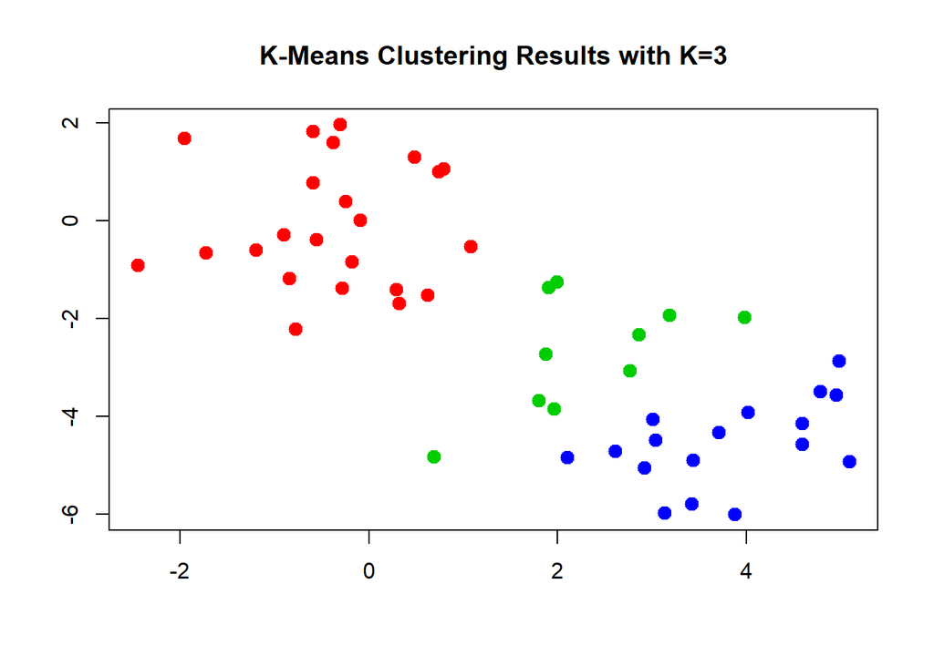

```r
plot(x, col = (km.out$cluster + 1),
     main = "K-Means Clustering Results with K=3",
     xlab = "", ylab = "", pch = 20, cex = 2)
```

We can look at the silhouette coefficient if we use the package ‘cluster’:

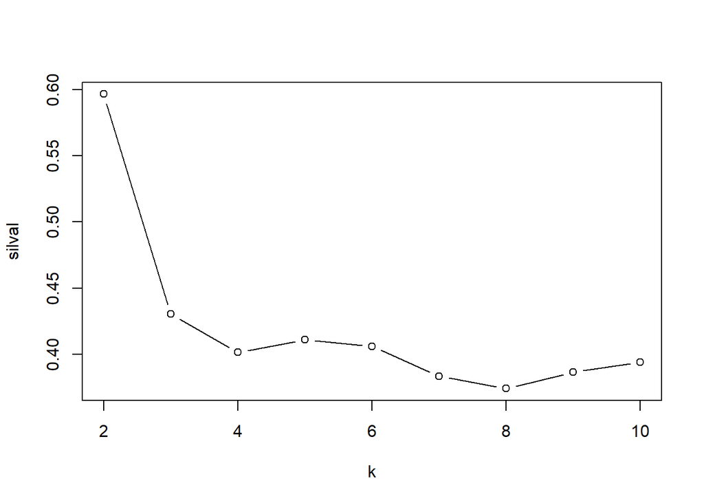

```r
library(cluster)
silval = rep(0, 9)
for (k in 2:10) {
  C = kmeans(x, k, nstart = 20)
  s = silhouette(C$cluster, dist(x))
  xx = summary(s)
  silval[k - 1] = xx$avg.width
}
plot(2:10, silval, xlab = "k", type = "b")
```

### Cluster analysis using hierarchical clustering

We first specify a distance matrix:

```r
EG = matrix(c(1, 2, 6, 2, 3, 1, 1, 3, 4, 5), nrow = 5, ncol = 2)
EG
```

```
##      [,1] [,2]
## [1,]    1    1
## [2,]    2    1
## [3,]    6    3
## [4,]    2    4
## [5,]    3    5
```

```r
dist(EG, 'manhattan', diag = TRUE, upper = TRUE)
```

```
##   1 2 3 4 5
## 1 0 1 7 4 6
## 2 1 0 6 3 5
## 3 7 6 0 5 5
## 4 4 3 5 0 2
## 5 6 5 5 2 0
```

We can hierarchically cluster the same data as we used in the K-means examples, but now using the three linkage methods:

```r
hc.complete = hclust(dist(x), method = "complete")
hc.average  = hclust(dist(x), method = "average")
hc.single   = hclust(dist(x), method = "single")
```

We can plot the three dendrograms on the same plot:

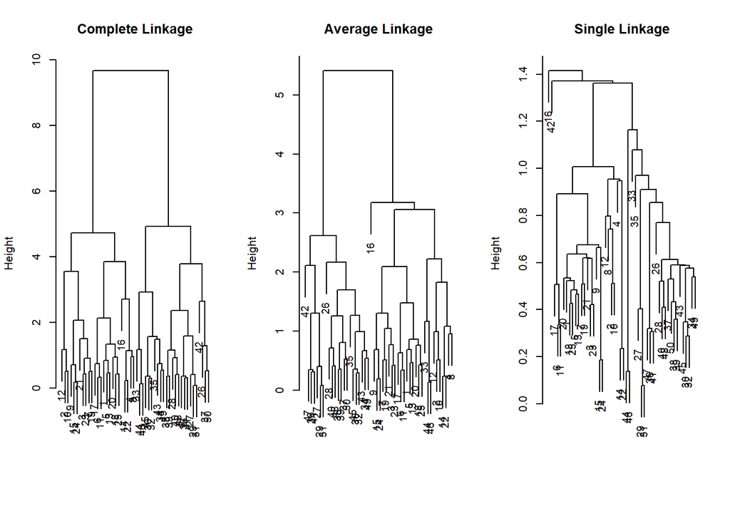

```r
par(mfrow = c(1, 3))
plot(hc.complete, main = "Complete Linkage", xlab = "", sub = "", cex = .9)
plot(hc.average,  main = "Average Linkage",  xlab = "", sub = "", cex = .9)
plot(hc.single,   main = "Single Linkage",   xlab = "", sub = "", cex = .9)
```

```r
par(mfrow = c(1, 1))
```

and cut the trees to define clusters:

```r
cutree(hc.complete, 2)
```

```
##  [1] 1 1 1 1 1 1 1 1 1 1 1 1 1 1 1 1 1 1 1 1 1 1 1 1 1 2 2 2 2 2 2 2 2 2 2
## [36] 2 2 2 2 2 2 2 2 2 2 2 2 2 2 2
```

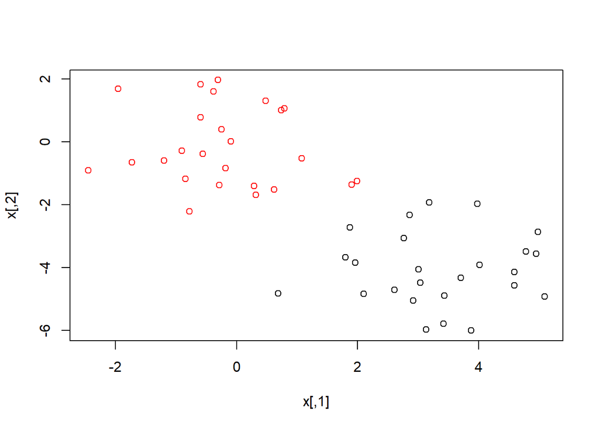

```r
plot(x, col = cutree(hc.complete, 2))
```

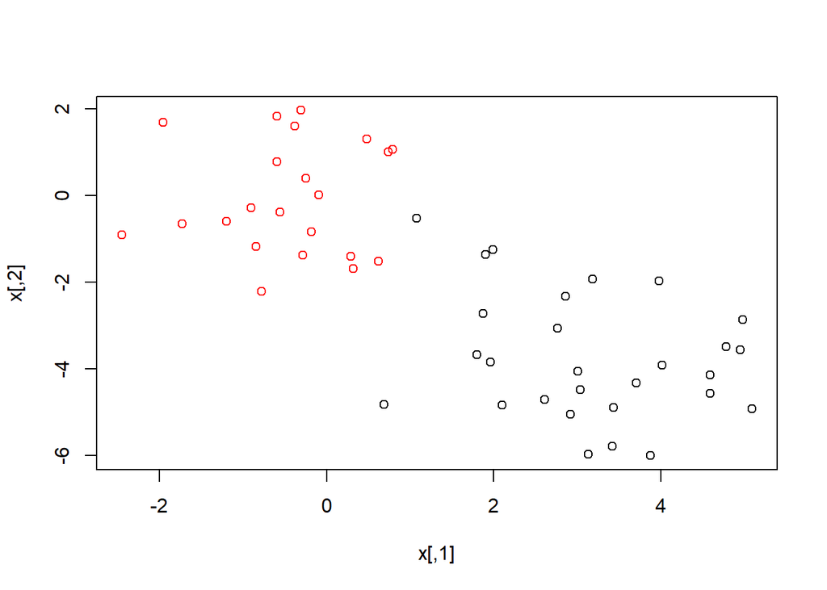

```r
plot(x, col = cutree(hc.average,  2))
```

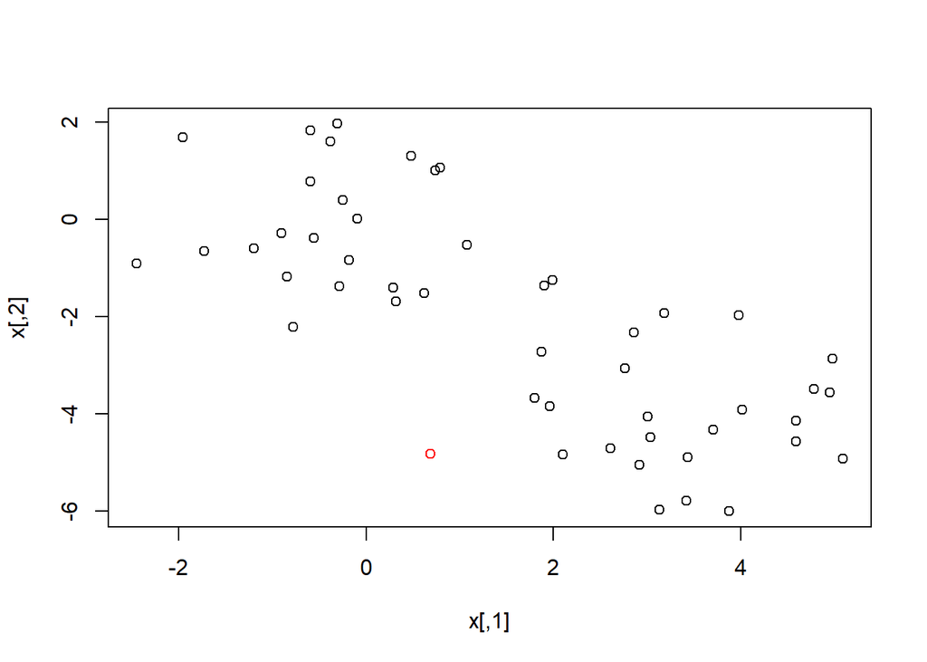

```r
plot(x, col = cutree(hc.single,   2))
```

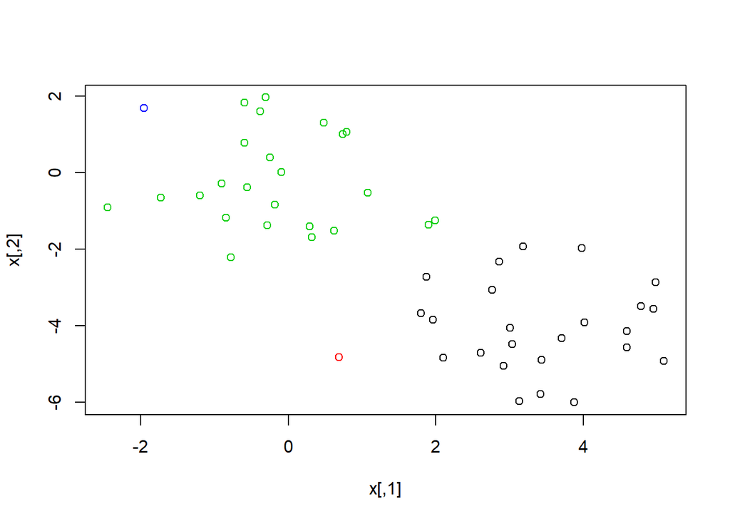

```r
plot(x, col = cutree(hc.single,   4))
```

## Second example data set

We construct a dataset to analyse using cluster analysis and hierarchical cluster analysis. In this second example, we write a function that generates bivariate normal random variables:

```r
rbivariate <- function(mean.x = 0, sd.x = 1, mean.y = 0, sd.y = 1, r = 0, n = 100) {
   z1 = rnorm(n)
   z2 = rnorm(n)
   x = sqrt(1 - r^2) * sd.x * z1 + r * sd.x * z2 + mean.x
   y = sd.y * z2 + mean.y
   return(cbind(x, y))
}
```

and then use this function to create a dataset to analyse using the K-means clustering and the hierarchical clustering algorithms.

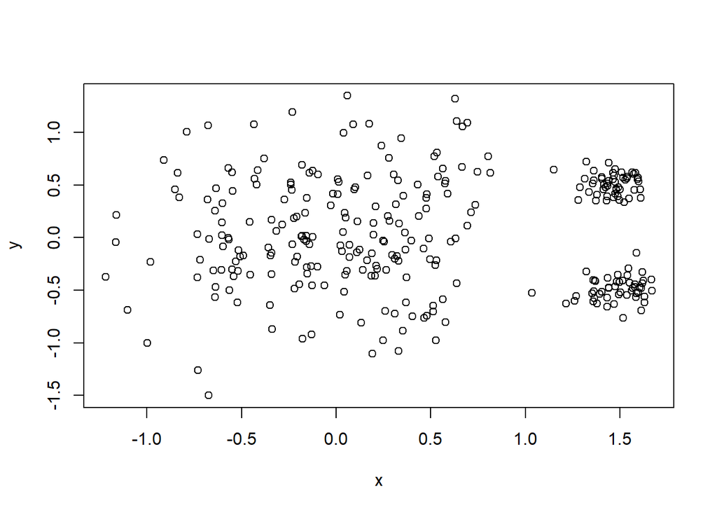

```r
set.seed(10)
c1 = rbivariate(mean.x = 1.5, sd.x = .1, mean.y = .5,  sd.y = .1, n = 50)
c2 = rbivariate(mean.x = 0,   sd.x = .5, mean.y = 0,   sd.y = .5, n = 200)
c3 = rbivariate(mean.x = 1.5, sd.x = .1, mean.y = -.5, sd.y = .1, n = 50)
mydata = rbind(c1, c2, c3)
plot(mydata)
```

### Cluster analysis using K-means clustering

We can repeat the same steps as we used in the first example, to explore how this clustering algorithm works:

```r
km.out = kmeans(mydata, 3)
km.out$tot.withinss
```

```
## [1] 94.36637
```

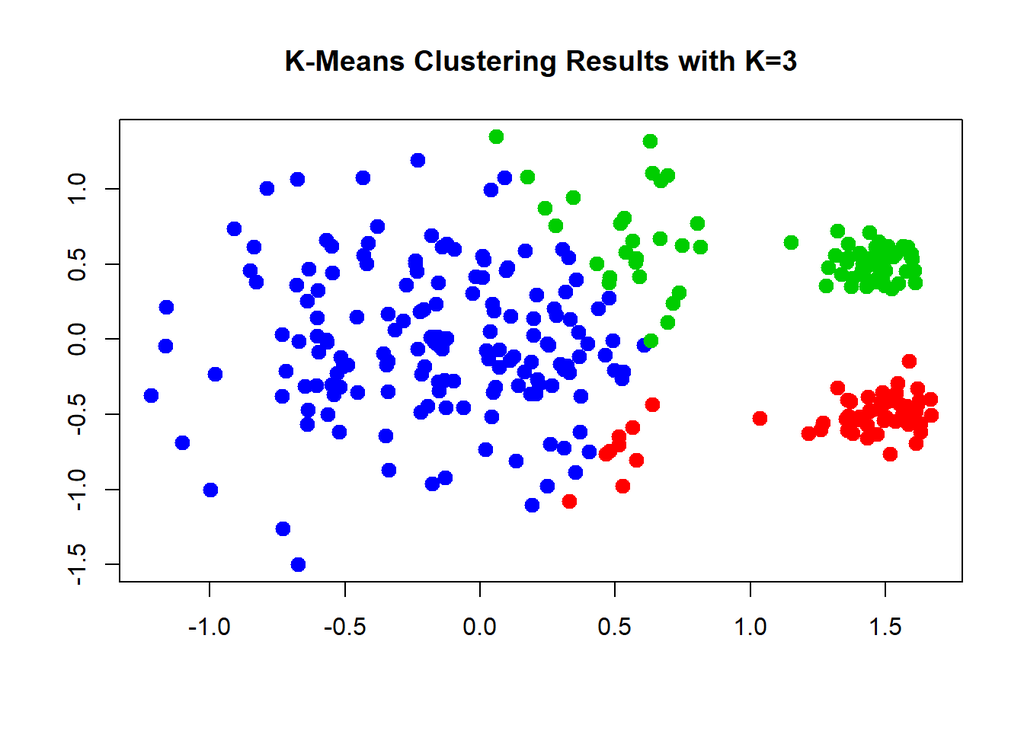

```r
plot(mydata, col = (km.out$cluster + 1),
     main = "K-Means Clustering Results with K=3",
     xlab = "", ylab = "", pch = 20, cex = 2)
```

Apply k-means for 3 clusters and with 1000 restarts (k=3):

```r
km.out = kmeans(mydata, 3, nstart = 1000)
km.out$tot.withinss
```

```
## [1] 90.04203
```

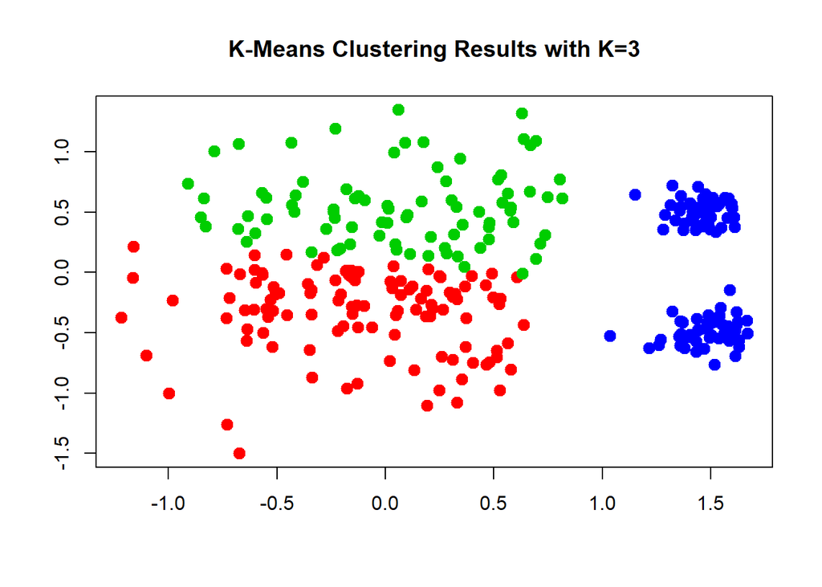

```r
plot(mydata, col = (km.out$cluster + 1),
     main = "K-Means Clustering Results with K=3",
     xlab = "", ylab = "", pch = 20, cex = 2)
```

Look at the silhouette coefficient:

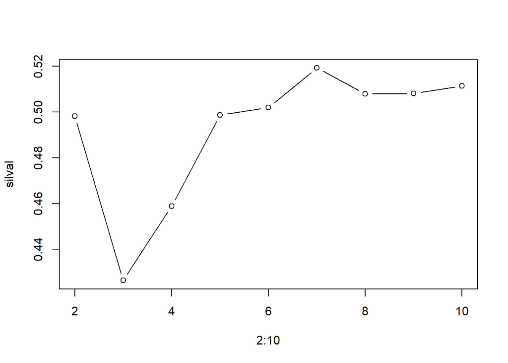

```r
library(cluster)
silval = rep(0, 9)
for (k in 2:10) {
  C = kmeans(mydata, k, nstart = 100)
  s = silhouette(C$cluster, dist(mydata))
  xx = summary(s)
  silval[k - 1] = xx$avg.width
}
plot(2:10, silval, type = "b")
```

Apply k-means for 7 clusters and with 100 restarts (k=7):

```r
km.out = kmeans(mydata, 7, nstart = 100)
km.out$tot.withinss
```

```
## [1] 27.40854
```

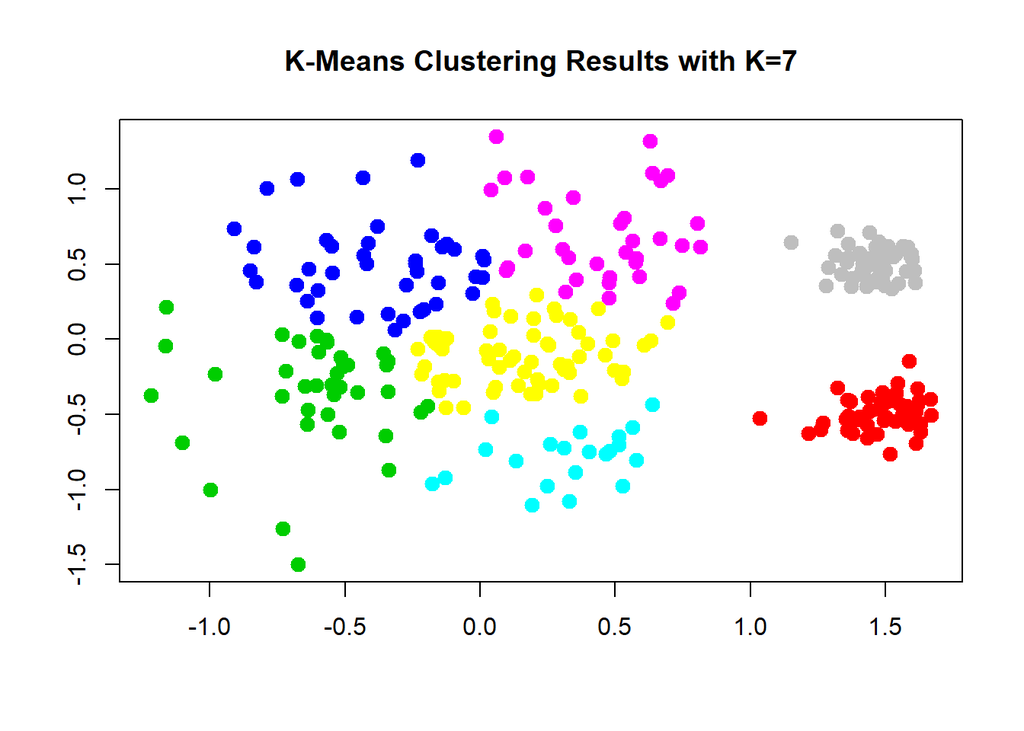

```r
plot(mydata, col = (km.out$cluster + 1),
     main = "K-Means Clustering Results with K=7",
     xlab = "", ylab = "", pch = 20, cex = 2)
```

We can also run the clustering algorithm with the ‘correct’ centres specified:

```r
km.out = kmeans(mydata,
                centers = rbind(c(1.5, 0.5), c(0, 0), c(1.5, -0.5)),
                nstart = 100)
km.out$tot.withinss
```

```
## [1] 94.24772
```

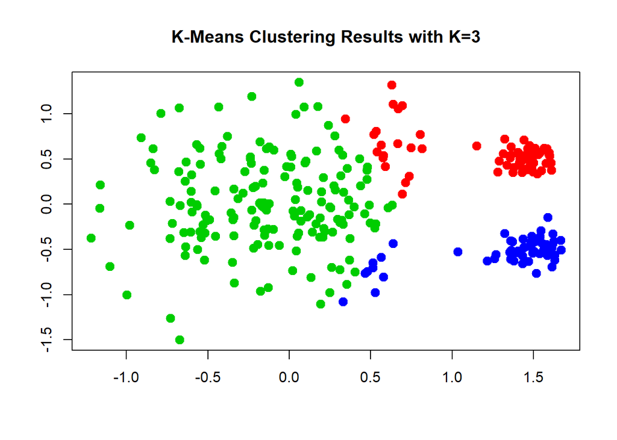

```r
plot(mydata, col = (km.out$cluster + 1),
     main = "K-Means Clustering Results with K=3",
     xlab = "", ylab = "", pch = 20, cex = 2)
```

### Cluster analysis using hierarchical clustering

We can analyse the data using complete, single, and average linkage, and compare the results:

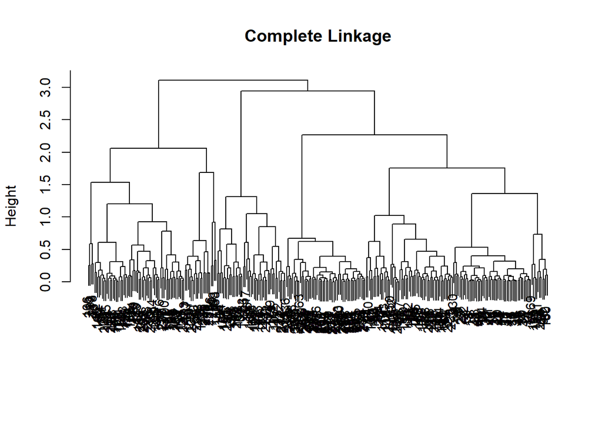

```r
hc.complete = hclust(dist(mydata), method = "complete")
plot(hc.complete, main = "Complete Linkage", xlab = "", sub = "", cex = .9)
```

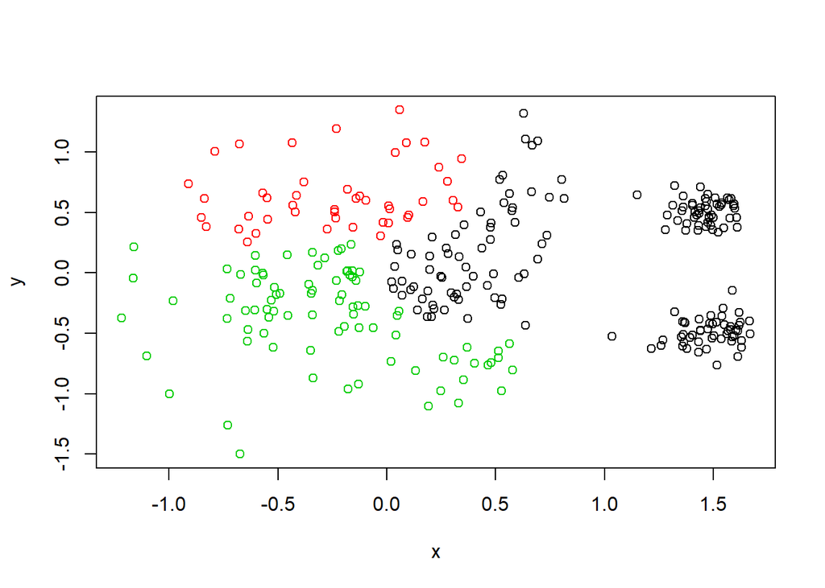

```r
plot(mydata, col = cutree(hc.complete, 3))
```

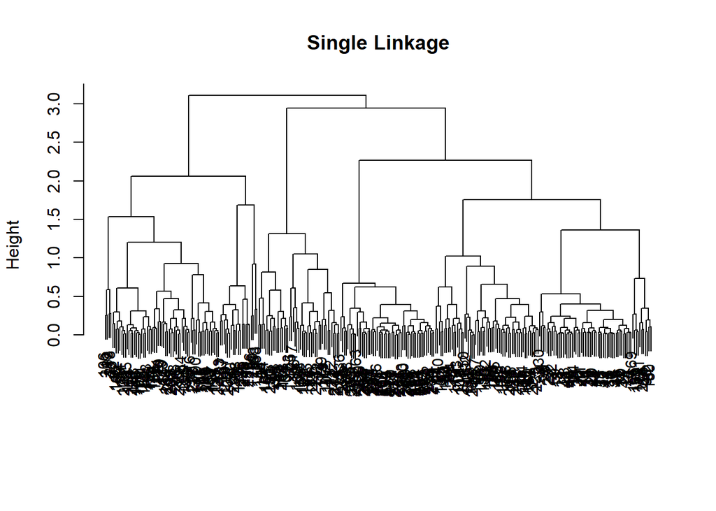

```r
hc.single = hclust(dist(mydata), method = "single")
plot(hc.complete, main = "Single Linkage", xlab = "", sub = "", cex = .9)
```

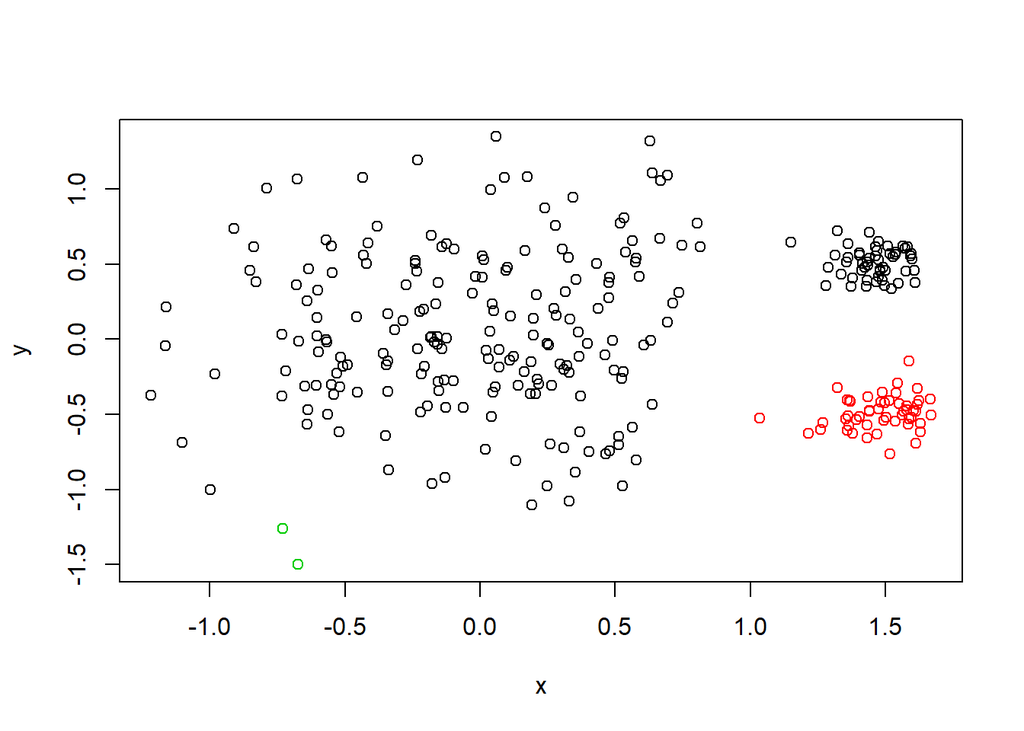

```r
plot(mydata, col = cutree(hc.single, 3))
```

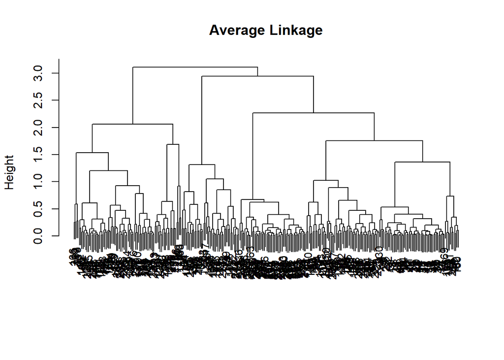

```r
hc.average = hclust(dist(mydata), method = "average")
plot(hc.complete,main = "Average Linkage", xlab = "", sub = "", cex = .9)
```

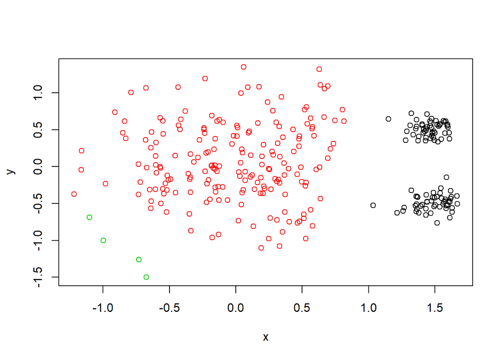

```r
plot(mydata, col = cutree(hc.average, 3))
```